# Comparison of Hierarchical Parent Proportion Tests

Adam Chan

20 October, 2021

# 1 Data Loading

The following datasets were used in this analysis:

CyTOF:

- Age Chronic Inflammation, Shen-Orr 2016  
  1036209 cells from 29 samples Predicting young/old from
- Anti-CTLA-4 and Anti-PD-1, Subrahmanyam 2018  
  7264780 cells from 24 samples Predicting response/nonresponse to treatment
- Anti-PD-1, Kreig 2018  
  85715 cells from 20 samples Predicting response/nonresponse to treatment
- Breast Cancer, Wagner 2019  
  855914 cells from 194 samples Predicting tumor/non-tumor breast cancer samples
- CMV, Davis 2019  
  18153877 cells from 69 samples Predicting positive/negative result from CMV titer in flu vaccine patients
- COVID-19 Whole blood CyTOF, Geanon 2021 4747543 cells from 21 hospitalized covid-19 patients and healthy controls

Flow Cytometry:

- AML, FlowCAP-II 2013  
  55711535 cells from 359 samples Predicting aml/normal patients
- COVID-19 PBMC, Humblet-Baron 2020  
  6510011 cells from 49 patients (6 health, 23 mild-to-moderate, 20 severe) samples Predicting mild vs severe COVID-19 through PBMC immune profile
- COVID-19 CD4 & CD8 T Cells, De Biasi 2020  
  12 Healthy controls and 19 covid patients
- COVID-19 CD8 Non Naive, Mathew 2020  
  54 healthy donors and 114 covid patients. Analysed 60% of the original cells which amounted to 11,591,741. Predicting between recovered donors and healthy donors
- MS HSCT, Ma 2020  
  Predicting between relapse and non-relapse patients recovering from stem cell transplant

scRNA-seq: - Melanoma, Sade-Feldman 2019

```r
#' Parent proportion test scripts
#' This script is to summarise results from the treeParentProportionTest.R Scripts

suppressPackageStartupMessages({
  library(ggplot2)
  library(dplyr)
  library(tidyr)
  library(gridExtra)
  library(ggnewscale)
  library(cowplot)
})

parClassificationFiles <- list.files("data/benchmarking_data/classification",
                                     full.names = TRUE)

load(file = parClassificationFiles[1])

parent_classif_df_combined <- allPredictions_df

for (i in 2:length(parClassificationFiles)){
  load(file = parClassificationFiles[i])

  parent_classif_df_combined <- parent_classif_df_combined %>%
    bind_rows(allPredictions_df)
}

#' ======================================================================
#' Comparison Visualisations
#' ----------------------------------------------------------------------

gg_theme <- theme_bw() +
  theme(panel.border = element_blank(),
        axis.line = element_line(color = 'black'))

cbp1 <- c("#e69f00", "#56b4e9", "#009e73", "#f0e442",
          "#cc79a7", "#0072b2", "#d55e00", "#999999",
          "#f27c7c", "#279a98", "#9a3f44", "#a53093",
          "#4c5e66")
```

# 2 Visualisations

## 2.1 Boxplot of Balanced Accuracy

Side-by-side cell proportions and proportion to parent

```r
bal_acc_df <- parent_classif_df_combined %>%
    mutate(dataset=ifelse(data_panel_name !="", paste(dataset, data_panel_name, sep=" - "), dataset)) %>%
    group_by(dataset, data_panel_name, task_id, learner_id, test_samp, iteration, cv_loop, truth) %>%
    summarise(bal_acc = mean(correct_bool), .groups="drop") %>%
    group_by(dataset, data_panel_name, task_id, learner_id, test_samp, iteration, cv_loop) %>%
    summarise(bal_acc = mean(bal_acc), .groups="drop") %>%
    # Average balance accuracies within each CV Loop
    group_by(dataset, data_panel_name, task_id, learner_id, test_samp, cv_loop) %>%
    summarise(bal_acc = mean(bal_acc), .groups="drop")

fun_mean <- function(x){
    return(data.frame(y=mean(x),label=round(mean(x,na.rm=T),2)))
}

# Means
bal_acc_means <- bal_acc_df %>%
  dplyr::filter(task_id %in% c("abs_prop_hc_avg", "parent_prop_hopach", "parent_prop_hc_avg") &
                  test_samp == "test_set" &
                  learner_id %in% c("classif.ranger")) %>%
  mutate(dataset=ifelse(data_panel_name !="", paste(dataset, data_panel_name, sep=" - "), dataset)) %>%
  group_by(dataset, task_id, learner_id, test_samp) %>%
  summarise(mean_bal_acc = mean(bal_acc), .groups="drop") %>%
  spread(key=task_id, value=mean_bal_acc) %>%
  rowwise() %>%
  mutate(parent_max = max(parent_prop_hc_avg, parent_prop_hopach)) %>%
  mutate(all_parent_diff = abs_prop_hc_avg - parent_max) %>%
  arrange(desc(all_parent_diff))


p <- ggplot(data = bal_acc_df %>%
              dplyr::filter(task_id %in% c("abs_prop_hc_avg", "parent_prop_hopach", "parent_prop_hc_avg") &
                              test_samp == "test_set" &
                              learner_id %in% c("classif.ranger"))%>%
              mutate(task_id = ifelse(task_id == "abs_prop_hc_avg",
                          "Prop. relative to all",
                          ifelse(task_id == "parent_prop_hc_avg",
                                 "Prop. relative to parent (using Hierarchical Clustering)",
                                 "Prop. relative to parent (using HOPACH)"))) ,
            aes(x=dataset, y=bal_acc,
                fill=task_id, col=task_id)) +
  geom_boxplot() +
  labs(title=paste0("Comparative Boxplot of Balanced Accuracy"),
       subtitle=paste0(5, "-fold CV with ", 20, " reps")) +
  scale_color_manual(values = cbp1) +
  scale_fill_manual(values = alpha(cbp1,0.3)) +
  gg_theme +
  theme(axis.text.x = element_text(angle = 60, vjust = 1, hjust=1,
                                   size=7),
        panel.grid.major = element_blank(),
        panel.grid.minor = element_blank()) +
  labs(y="Balanced Accuracy",
       x="Dataset",
       fill="Features used",
       col="Features used")

# Rank of mean and variance
classif_res_rank <- bal_acc_df %>%
  mutate(dataset=ifelse(data_panel_name !="", paste(dataset, data_panel_name, sep=" - "), dataset)) %>%
  dplyr::filter(task_id %in% c("abs_prop_hc_avg", "parent_prop_hopach", "parent_prop_hc_avg") &
                  test_samp == "test_set" &
                  learner_id %in% c("classif.ranger")) %>%
  mutate(task_id = ifelse(task_id == "abs_prop_hc_avg",
              "Prop. relative to all",
              ifelse(task_id == "parent_prop_hc_avg",
                      "Prop. relative to parent (using Hierarchical Clustering)",
                      "Prop. relative to parent (using HOPACH)"))) %>%
  group_by(dataset, task_id, learner_id, test_samp) %>%
  summarise(mean_bal_acc = mean(bal_acc),
            var_bal_acc = var(bal_acc), .groups="drop") %>%
  group_by(dataset,learner_id, test_samp) %>%
  mutate(`CV Balanced Accuracy Mean Rank` = rank(-mean_bal_acc, ties.method= "max"),
         `CV Balanced Accuracy Variance Rank` = rank(var_bal_acc, ties.method= "max")) %>%
  ungroup() %>%
  select(-mean_bal_acc, -var_bal_acc) %>%
  pivot_longer(c(`CV Balanced Accuracy Mean Rank`, `CV Balanced Accuracy Variance Rank`),
                names_to="var", values_to="res_rank")

pr <- ggplot(classif_res_rank) +
  geom_point(aes(x=dataset, y=task_id,
                  size=factor(res_rank, levels=c(3,2,1)),
                  col=factor(res_rank, levels=c(3,2,1)))) +
  facet_wrap(~var, nrow=2) +
  theme_bw() +
  theme(axis.text.x = element_blank(),
        strip.background = element_blank()) +
  scale_color_manual(values=alpha(c("#C2FCF7", "#85BDBF", "#57737A"), 0.75)) +
  labs(size="Rank", col="Rank",
       x="", y="Features Used")
```

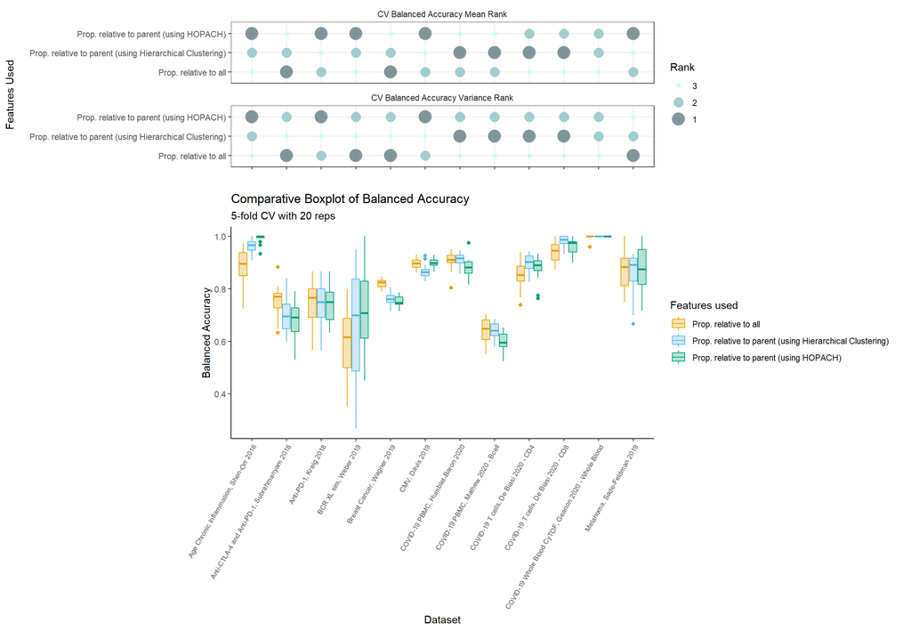

```r
# Export as 9x13 for treekoR paper
plot_grid(pr, p,
          nrow=2,
          align="v",
          axis="lr",
          rel_heights=c(0.85,2))
```